# Economics & Crime: An Introductory Investigation

Greetings & Salutations.

My name is Chase M. Frederick and I am a Master's candidate, here, at Tulane University. I'm privliaged enough to say I am a a part of the first cohort (Cohort-0) for the Political Economy & Data Analytics program started this year.

In this report, I will conduct a cursory investigation into the The Violent Crime Control and Law Enforcement Act of 1994 (1994 Crime Bill), and it's effects on crime rates (specifically, violent crime rates), and per capita Gross Domestic

Product (GDP) in the United States. To do this, I will utlilize several datasets & several data analytical techniques, including, but not limited to, regression & graphical analysis. The question I would like to answer is: Too what

extent, did the 1994 Crime Bill actually effect arrest & crime rates. and secondarly, to what extent did the 1994 crime bill, by way of crime and arrests, exert any infleunce on economic output and trends. I believe if a meaningful answer can be

produced here in, it may be used for diagnosing how potent changes to policy can be on the real world and how much of an impact they may have on people's lives.

The affirmative undergurding assumption here is that, crime has a depressive effect on economic output, and as such, the alivation of it, should improve economic markers. In a snese, I'm using economic output as a Instrumental Variable (IV)

(allbeit, a weak one due to the obvious violation of the exclusion rule) for the 1994 crime bill's effects.

## Data Sources

The data I will be using throughout the durartion of this presentation are listed and located as follows:

Penn-World Tables 2022 dataset including relavent economic markets: https://www.rug.nl/ggdc/productivity/pwt/?lang=en

Rate of Violent & Non-violent property crime by year: https://crime-data-explorer.fr.cloud.gov/pages/explorer/crime/crime-trend

## Data Description & Key Variables

The year variable is just the year of the observation in question. Below, you will find a table below inclduing all Penn world variables and their descriptive statistics.

```python
import numpy as np
import pandas as pd
import statsmodels.formula.api as smf
import matplotlib.pyplot as plt
import seaborn as sns
from sklearn.preprocessing import StandardScaler

import warnings
warnings.filterwarnings('ignore')

penn = pd.read_excel("pwt100.xlsx")
violence = pd.read_csv("allcrime.csv")
property = pd.read_csv("allproperty.csv")

penn[['cgdpo', 'avh', 'pop', 'csh_c']].describe()
```

|  | cgdpo | avh | pop | csh_c |
| --- | --- | --- | --- | --- |
| count | 1.039500e+04 | 3492.000000 | 10399.000000 | 10399.000000 |
| mean | 3.061624e+05 | 1986.923200 | 30.962982 | 0.643305 |
| std | 1.224439e+06 | 284.003338 | 116.189454 | 0.300476 |
| min | 1.693567e+01 | 1380.607643 | 0.004425 | -11.800017 |
| 25% | 6.811935e+03 | 1788.478805 | 1.579663 | 0.535802 |
| 50% | 3.049679e+04 | 1972.355973 | 6.150688 | 0.637181 |
| 75% | 1.559250e+05 | 2168.035042 | 19.934229 | 0.752748 |
| max | 2.056603e+07 | 3039.794005 | 1433.783686 | 11.056113 |

## Data description & Key Variables Continued.

```python
violence.describe()
```

|  | year | US_C Rate |
| --- | --- | --- |
| count | 36.000000 | 36.000000 |
| mean | 2002.500000 | 522.805556 |
| std | 10.535654 | 128.605423 |
| min | 1985.000000 | 361.600000 |
| 25% | 1993.750000 | 398.250000 |
| 50% | 2002.500000 | 486.850000 |
| 75% | 2011.250000 | 624.225000 |
| max | 2020.000000 | 758.200000 |

```python
property.describe()
```

|  | year | US_P Rate |
| --- | --- | --- |
| count | 36.000000 | 36.000000 |
| mean | 2002.500000 | 3675.191667 |
| std | 10.535654 | 995.622687 |
| min | 1985.000000 | 1958.200000 |
| 25% | 1993.750000 | 2896.050000 |
| 50% | 2002.500000 | 3604.750000 |
| 75% | 2011.250000 | 4661.750000 |
| max | 2020.000000 | 5140.200000 |

## Methodology & Analytical Framework

The method used to infer casuality in this report will be the use of Ordinary Least Squares Estimation (OLS), with a Difference-In-Difference framework (DiD). Any and all use of reobust standard errors will use the "HC1" method of aggration as to produce output similar to that of Stata and other commercial statistical software. I will me using the Statsmodels library (SMF), to implement these techniques.

Difference-in-Difference is a estimation model that utilizes Dummy variables to indicate treatment and control groups, and being pre/post treatment. The model also uses an interaction term to show the combind effect of being in the treatment group post treatment to estimate the effects. For this report, The United States will be the treatment group, while the United Kingdom will be the control group.

Also of note, the crime data is standardized to the per 100,000 level while our Penn World data is not standardized and is reported in the millions. Before causal analysis begins, I will be standardizing the Penn World data. For the graphical analysis, I will be using a mixture of the Seaborn (SNS) and Matplotlib (plt) libraries.

# Graphical Analysis

Let's get an idea of what the economic trend looks like in per capita GDP (pc_gdp), over time in our dataset. Below, I'll be showing the yearly trend in Per Capita GDP (pc_gdp) for one country per continent to give a global perspective.

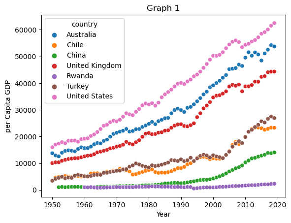

```python
country = ['United States', 'China', 'Rwanda', 'United Kingdom', 'Chile', 'Australia', 'Turkey']
data_2 = penn[penn["country"].isin(country)]

# Create Per Capita GDP Variable (Output side, in millions)

data_2['pc_gdp'] = data_2['cgdpo'] / data_2['pop']

pc_graph = sns.scatterplot(x='year', y='pc_gdp', hue="country", data=data_2)

pc_graph.set(xlabel="Year", ylabel='per Capita GDP', title='Graph 1')
plt.savefig('Per_Capita.png')
```

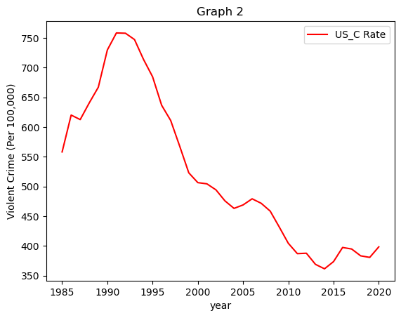

```python
violence.plot.line(x='year', y='US_C Rate', title='Graph 2',
color='red').set_ylabel('Violent Crime (Per 100,000)')
plt.savefig('Graph02.png')
```

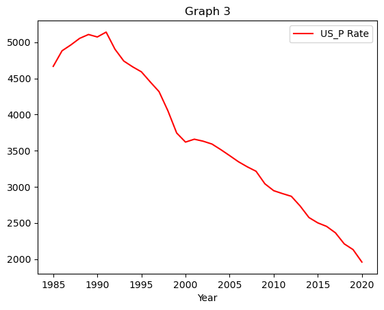

```python
# looking at property crime trends

property.plot.line('year', 'US_P Rate', title='Graph 3', color='red').set_xlabel('Year')
```

looking at both graphs, there seems to be peak in both forms of crime in the early 90s and a steep drop off thereafter. At a glance, the data seems to line up with the assumption that the 1994 Crime Bill had a meaningful effect on the crimes rates for both violent and property crime.

Below, I will be preparing the data by merging the criem data with the Penn World data.

```python
# Merge the data together for eaiser comparison.

data = penn.merge(violence, on=['year', 'country'], how='outer')

data = data.merge(property, on=['year', 'country'], how='outer')

# Creating new variables that have easier names ot enter for analysis.

data['pc_gdp'] = data['cgdpo'] / data['pop']

data['vc_rate'] = data['US_C Rate']

data['pc_rate'] = data['US_P Rate']

# Creating logs of our key variables for easier interpretation and to control for heterosckadisity.

data['lpc_gdp'] = np.log(data['pc_gdp'])
data['lvc_rate'] = np.log(data['vc_rate'])
data['lpc_rate'] = np.log(data['pc_rate'])

# Create a new dataset that only consists of data betwen the years 1985 & 2020 within the United States.

data_02 = data[(data['year']>= 1985) & (data['year']<= 2020) & (data['country'] == 'United States') | (data['country'] == "United Kingdom")]
data_02[["pc_gdp", 'vc_rate', 'pc_rate', 'avh', 'csh_c']].describe()
```

|  | pc_gdp | vc_rate | pc_rate | avh | csh_c |
| --- | --- | --- | --- | --- | --- |
| count | 105.000000 | 36.000000 | 36.000000 | 105.000000 | 105.000000 |
| mean | 32838.638082 | 522.805556 | 3675.191667 | 1813.542013 | 0.672150 |
| std | 15465.273026 | 128.605423 | 995.622687 | 144.189777 | 0.028759 |
| min | 10045.512717 | 361.600000 | 1958.200000 | 1638.331733 | 0.606107 |
| 25% | 18000.587827 | 398.250000 | 2896.050000 | 1721.195442 | 0.652828 |
| 50% | 35482.243337 | 486.850000 | 3604.750000 | 1780.839365 | 0.672634 |
| 75% | 44093.933830 | 624.225000 | 4661.750000 | 1839.196147 | 0.694550 |
| max | 62498.409698 | 758.200000 | 5140.200000 | 2192.663847 | 0.759771 |

This table looks good be I need to also scale the economic figures to match the data same range as the crime figures. I'll do that below.

```python
scaler = StandardScaler()
data_02[['pop', 'pc_rate', 'pc_gdp', 'emp', 'vc_rate', 'csh_c', 'avh']] = scaler.fit_transform(data_02[['pop', 'pc_rate', 'pc_gdp', 'emp', 'vc_rate', 'csh_c', 'avh']])
data_02[['pop', 'pc_rate', 'pc_gdp', 'emp', 'vc_rate', 'csh_c', 'avh']]
```

|  | pop | pc_rate | pc_gdp | emp | vc_rate | csh_c | avh |
| --- | --- | --- | --- | --- | --- | --- | --- |
| 4270 | -0.765707 | NaN | -1.480895 | -0.758556 | NaN | 3.061343 | 2.581169 |
| 4271 | -0.764213 | NaN | -1.463180 | -0.751964 | NaN | 1.852697 | 2.641936 |
| 4272 | -0.762929 | NaN | -1.461958 | -0.752212 | NaN | 1.344982 | 2.420299 |
| 4273 | -0.761434 | NaN | -1.425993 | -0.750059 | NaN | 1.166501 | 2.447625 |
| 4274 | -0.759857 | NaN | -1.402910 | -0.743677 | NaN | 1.262842 | 2.476552 |
| ... | ... | ... | ... | ... | ... | ... | ... |
| 12176 | 1.739695 | -1.246404 | 1.707497 | 1.707844 | -0.988162 | 1.086411 | -0.326114 |
| 12177 | 1.758684 | -1.336758 | 1.772278 | 1.751284 | -1.008666 | 1.116026 | -0.347142 |
| 12178 | 1.777148 | -1.492712 | 1.864550 | 1.789535 | -1.099355 | 1.031760 | -0.270647 |
| 12179 | 1.795219 | -1.573389 | 1.927029 | 1.820534 | -1.119859 | 1.084876 | -0.335854 |
| 12810 | NaN | -1.749003 | NaN | NaN | -0.980276 | NaN | NaN |

106 rows × 7 columns

# Statistical Analysis

Now that we have the data we're looking for, Let's build and run a regression model where the total violent crime rate (vc_rate) is explained by a linear combination of the per capita gdp (pc_gdp), year, and share of household consumption at current levels (PPP)(csh_c).

The reason for the addition of csh_c may not be immediately obvious. The inclusion of the csh_c variable is an attmept to capture the gap between the broad per cpaita GDP peasure (pc_gdp), and the real world of effects it may have which would be reflecte in an increase, or decrease, in household consumption.

```python
formula = 'vc_rate ~ pc_gdp + year + csh_c'

model = smf.ols(formula, data_02).fit()
print(model.summary(title='Table 1'))
```

```
                                   Table 1
==============================================================================
Dep. Variable:                vc_rate   R-squared:                       0.826
Model:                            OLS   Adj. R-squared:                  0.809
Method:                 Least Squares   F-statistic:                     49.01
Date:                Thu, 15 Dec 2022   Prob (F-statistic):           7.13e-12
Time:                        17:01:33   Log-Likelihood:                -19.080
No. Observations:                  35   AIC:                             46.16
Df Residuals:                      31   BIC:                             52.38
Df Model:                           3
Covariance Type:            nonrobust
==============================================================================
                 coef    std err          t      P>|t|      [0.025      0.975]
------------------------------------------------------------------------------
Intercept    113.5654     85.809      1.323      0.195     -61.443     288.574
pc_gdp        -1.4855      0.837     -1.774      0.086      -3.193       0.222
year          -0.0560      0.043     -1.295      0.205      -0.144       0.032
csh_c          0.6818      0.271      2.511      0.017       0.128       1.236
==============================================================================
Omnibus:                        0.347   Durbin-Watson:                   0.293
Prob(Omnibus):                  0.841   Jarque-Bera (JB):                0.352
Skew:                          -0.211   Prob(JB):                        0.839
Kurtosis:                       2.748   Cond. No.                     2.29e+06
==============================================================================

Notes:
[1] Standard Errors assume that the covariance matrix of the errors is correctly specified.
[2] The condition number is large, 2.29e+06. This might indicate that there are
strong multicollinearity or other numerical problems.
```

The regression specified above has a 'Goodness-of-fit' measure (r-squared) of .826, which is pretty good. The closer the R-squared is to 1, the more of the vairence of our data is explained by the model. moreover, all of our variables are significant at the .10 level save for the year variable.

Now, for the real question: what effect does being after 1994 (post) have along with the effect of post 1994 per capita gdp have?

```python
# Creating Post 1994 variable
data_02['post'] = np.where(data_02['year']>=1994, 1, 0)

# Creating Treatment variable
data_02['treatment'] = np.where(data_02.country == "United States", 1, 0)
# Creating post 1994 gdp variable
data_02['post_gdp'] = data_02['post'] * data_02['pc_gdp']
# reating Post Treamtment variable
data_02['post_treatment'] = data_02['treatment']*data_02['post']
# Creating Post Treamtnet per capita GDP variable.
data_02['post_treatment_gdp'] = data_02['post']*data_02['treatment']*data_02['pc_gdp']


formula = 'vc_rate ~ post + treatment + post_treatment'

model = smf.ols(formula, data_02).fit(cov_type='HC1')
print(model.summary(title='Table 2'))
```

```
                                   Table 2
==============================================================================
Dep. Variable:                vc_rate   R-squared:                       0.491
Model:                            OLS   Adj. R-squared:                  0.476
Method:                 Least Squares   F-statistic:                     24.34
Date:                Thu, 15 Dec 2022   Prob (F-statistic):           2.75e-07
Time:                        17:01:34   Log-Likelihood:                -38.915
No. Observations:                  36   AIC:                             81.83
Df Residuals:                      34   BIC:                             85.00
Df Model:                           1
Covariance Type:                  HC1
==================================================================================
                     coef    std err          z      P>|z|      [0.025      0.975]
----------------------------------------------------------------------------------
Intercept          0.6070      0.094      6.438      0.000       0.422       0.792
post              -0.8094      0.121     -6.709      0.000      -1.046      -0.573
treatment          0.6070      0.094      6.438      0.000       0.422       0.792
post_treatment    -0.8094      0.121     -6.709      0.000      -1.046      -0.573
==============================================================================
Omnibus:                        5.914   Durbin-Watson:                   0.177
Prob(Omnibus):                  0.052   Jarque-Bera (JB):                4.955
Skew:                           0.902   Prob(JB):                       0.0839
Kurtosis:                       3.217   Cond. No.                     5.13e+16
==============================================================================

Notes:
[1] Standard Errors are heteroscedasticity robust (HC1)
[2] The smallest eigenvalue is 4.47e-32. This might indicate that there are
strong multicollinearity problems or that the design matrix is singular.
```

The model specifed above has a 'Goodness-of-Fit' measure of .491 and a F-stat of 24.34 which means our model explains less than half of the variance in our dataset, and is statistically meaningful since the F-stat cutoff has to be a minimum of 10. All of the variables in our model are significant at the .001 level and below.

Based off the results, jsut being in the treatment group increase violent crime by .60 while being in the treatment group, post treatment, has a negative .80 effect on violent crime. Now, what is the effect of per cpaita gdp of the treatment group, post treatment?

```python
formula = 'vc_rate ~ post + treatment + pc_gdp + post_treatment_gdp '

model = smf.ols(formula, data_02).fit(cov_type='HC1')
print(model.summary(title='Table 3'))
```

```
                                   Table 3
==============================================================================
Dep. Variable:                vc_rate   R-squared:                       0.922
Model:                            OLS   Adj. R-squared:                  0.915
Method:                 Least Squares   F-statistic:                     93.49
Date:                Thu, 15 Dec 2022   Prob (F-statistic):           7.69e-17
Time:                        17:01:35   Log-Likelihood:                -4.9674
No. Observations:                  35   AIC:                             17.93
Df Residuals:                      31   BIC:                             24.16
Df Model:                           3
Covariance Type:                  HC1
======================================================================================
                         coef    std err          z      P>|z|      [0.025      0.975]
--------------------------------------------------------------------------------------
Intercept             -0.2569      0.082     -3.119      0.002      -0.418      -0.095
post                   2.8045      0.311      9.028      0.000       2.196       3.413
treatment             -0.2569      0.082     -3.119      0.002      -0.418      -0.095
pc_gdp                 4.3708      0.448      9.756      0.000       3.493       5.249
post_treatment_gdp    -6.3952      0.492    -13.005      0.000      -7.359      -5.431
==============================================================================
Omnibus:                        4.549   Durbin-Watson:                   0.629
Prob(Omnibus):                  0.103   Jarque-Bera (JB):                1.831
Skew:                           0.138   Prob(JB):                        0.400
Kurtosis:                       1.914   Cond. No.                     7.87e+16
==============================================================================

Notes:
[1] Standard Errors are heteroscedasticity robust (HC1)
[2] The smallest eigenvalue is 2.93e-32. This might indicate that there are
strong multicollinearity problems or that the design matrix is singular.
```

In the regression table 3 above, it seems that there is now a postive association with the post cutoff date variable showing that being past the cut off has a 2.8 positive effect on the violent crime rate. Treatment is now negatively associated

with a being part of the treatment group having a .25 depressive effect on the the violent crime rate.

association of 6.39.

# Model Limitations & Further Research

The Models above are a rough estimation of the effects of the 1994 Crime Bill and it's effects on violent crime. While a more grainular picture would have been prefer, so that causuality could be determined, these rudimentary associations will

surve as a jump-off point for further. formally improved research. This research can be improved by findind more grainular crime data inlarge metro areas such as Los Angeles, Chicago, New York and Boston. The addition of the metrics would allow for

more constrast and balance between the the more rural areas in the data. Furhtermore, the addition of the metro area data would allow for estimation using an "Intensity of Treatment" design, allowing us to drill down and see what effects did the

laws have on specific, high crime areas. Further still, in contrast, we could take a more macro apporach and aggregate country-level data across the world for every country present in the Penn-world data, allowing for a large, country-level

Difference-in-Difference estimation with many countrols groups. An additional limitation of the data and models above includes the swithcing of the violent crime stat in the regression with the per capita GDP figures. my original goal was to

estimate the effects of crime on per capita gdp with the understandind that, crime has a depressive effect on economic figures. The reason for the switch was due ot the nature of hte underlying data. I simply have a better picture of the economic

factors than I do the crime factors. My understand is that, to use htme in their origianl order may lead to spurious correlation and misleading results. To avoid this, I sought to explain the rough picture with finer details, rather than, explain

the detailed picture with rough details.

# Conclusions

Based off the results from regression table 2-3, I would say that there is reason/evidence ot believe that this subject has legs to stand and could, with a more careful research design and better data sources, could be developed into a journal

quality submission. We saw, in the regressions above, the models did have explanitory power and did have meanigful controls, but the models also had large conditional numbers, which may mean the variables have some strong colinearity preasent.

was a favored criem dataset that contain more accurate and grainular crime statistics that were broken down by office and unstandardized for easier use. I would like to see this analysis don again with that data for a more flexable and palatable

estimation. All in all, I believe this report gives good cause for further invesitgation of the effects of the 1994 Crime Bill and warrents further professional review.